# BoneCellType: R package for bone-relevant cell type assignment

Kristyna Kupkova

2023-09-24

# Introduction to BoneCellType

The BoneCellType package aims to help assign cell types to single-cell RNA-seq clusters derived from bone samples. BoneCellType uses a custom-assembled database of bone-relevant markers (assembly approach described [here](https://github.com/kkupkova/Mouse-bone-markers)). There are two approaches introduced here to reach this goal: 1) marker overrepresentation analysis using Fisher’s exact test, and 2) gene (marker) set enrichment analysis.

**Note!** The results produced with BoneCellType do not assign definitive cell-type labels; only an initial prediction based on statistical testing and further manual curation is needed.

# Setup

Let’s load the BoneCellType package along with a few other packages whose functions are used in this tutorial.

The input into the functions presented here is a data.frame with variable markers (i.e. features) for individual clusters that can be obtained by using [Seurat](https://satijalab.org/seurat/) `FindMarkers` function. Here we provide a previously generated example dataset.

```r
library(BoneCellType)
library(dplyr)
library(ggplot2)

# example dataset
varMarkerFile = system.file("extdata", "cluster_variable_features.csv",
                            package = "BoneCellType")
varMarkers = read.csv(varMarkerFile, sep = ",")

# show top rows of the example dataset
head(varMarkers)
```

```
#>           p_val avg_log2FC pct.1 pct.2     p_val_adj cluster   gene
#> 1 1.551369e-202   7.978416 0.664 0.021 2.861810e-198       0  Hemgn
#> 2 5.127751e-104  16.393282 0.935 0.169 9.459163e-100       0  Mki67
#> 3  4.012367e-98   5.801448 0.701 0.078  7.401614e-94       0 Diaph3
#> 4  4.156995e-96  11.168982 0.776 0.107  7.668409e-92       0   Ank1
#> 5  1.869814e-87   8.421892 0.776 0.120  3.449246e-83       0   Sptb
#> 6  1.936041e-87   7.841105 0.785 0.123  3.571415e-83       0  Top2a
```

# 1. Marker overrepresentation analysis

To calculate marker overrepresentation use `markerEnrich` function. It automatically provides a database of bone-relevant markers. Results can be further dirrectly plotted with an associated `plotMarkerEnrich` function, output of which is an editable *ggplot* object.

**Note**: While the default setting of `markerEnrich` use all available variable markers per cluster, based on practical experience, more reliable results can be achieved by selecting only few top markers by setting the parameter *topN* (as shown in the example below). Default mode selects the top markers based on log2FC, this can be changed by setting the parameter *sortBy=“padj*”. Changing the* sortBy*, however, usually does not change much.

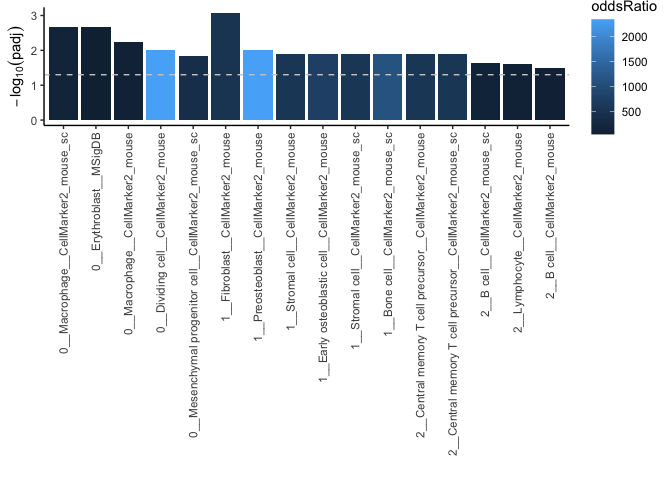

```r
# run overrepresentation analysis uasing top 10 variable markers (features) per cluster
ORres = markerEnrich(varMarkers, topN = 10)

# plot the top 5 most significant results
plotMarkerEnrich(ORres, topN = 5)
```

Let’s now have a look at the format of the `markerEnrich` results.

```r
# show top 2 significant result for each cluster
topORres = ORres %>%
  group_by(cluster) %>%
  top_n(n = 2, wt = neg_log10_padj)

topORres
```

```
#> # A tibble: 6 × 9
#> # Groups:   cluster [3]
#>   cluster cellType           database       p oddsRatio n_olaps overlaps    padj
#>     <int> <chr>              <chr>      <dbl>     <dbl>   <int> <chr>      <dbl>
#> 1       0 Macrophage         CellMar… 1.05e-4     169.        2 Mki67,T… 2.20e-3
#> 2       0 Erythroblast       MSigDB   7.99e-5      48.4       3 Top2a,C… 2.20e-3
#> 3       1 Fibroblast         CellMar… 1.32e-5     515.        2 Col1a2,… 8.31e-4
#> 4       1 Preosteoblast      CellMar… 9.43e-4    2339.        1 Col1a1   9.90e-3
#> 5       2 Central memory T … CellMar… 2.36e-3     574.        1 Lef1     1.24e-2
#> 6       2 Central memory T … CellMar… 2.36e-3     574.        1 Lef1     1.24e-2
#> # ℹ 1 more variable: neg_log10_padj <dbl>
```

As shown, the output is a table with following variables- *cluster*: cluster number / *cellType*: cell type / *database*: source database from which markers originate / *p*: p-value / *oddsRatio*: odds ratio / *n_olaps*: number of overlap between variable markers (features) and the marker database / *overlaps*: list of individual overlapping markers / *padj*: adjusted p-value /*neg_log10_padj*: -log10(padj).

**Recommendation:** Try few different settings of the `markerEnrich` function try different *topN*, *sortBy* arguments. In general I wouldn’t set the *byDatabase* to FALSE, as the TISSUES database has relatively a lot of markers (some of which I am not too sure about) and it can skew the results. But overall I definitely recommend to explore the whole result table, to see which markers drive associated results and if that cell type assignment then makes sense.

# 2. Gene (marker) set enrichment analysis